# Data Project : Taylor Swift

# How has the lyrics of Taylor Swift's music changed over time?

## Cleaning and Preparing Data

importing the packages that we're going to need:

```python
import pandas as pd
import matplotlib.pyplot as plt
import numpy as np
```

importing the data for each album as a data frames:

```python
debut = pd.read_csv("01-taylor_swift.csv")
speaknow = pd.read_csv("03-speak_now_deluxe_package.csv")
red = pd.read_csv("04-red_deluxe_edition.csv")
nineteen89 = pd.read_csv("05-1989_deluxe.csv")
rep = pd.read_csv("06-reputation.csv")
lover = pd.read_csv("07-lover.csv")
folk = pd.read_csv("08-folklore_deluxe_version.csv")
ever = pd.read_csv("09-evermore_deluxe_version.csv")
fearless = pd.read_csv("02-fearless_taylors_version.csv")
```

renaming columns in the data frames:

```python
debut.rename({"album_name" : "Album", "track_title":"Track Title", "track_n":"Track Number"},
             axis = 1, inplace = True)

speaknow.rename({"album_name" : "Album", "track_title":"Track Title", "track_n":"Track Number"},
                axis = 1, inplace = True)

red.rename({"album_name" : "Album", "track_title":"Track Title", "track_n":"Track Number"},
           axis = 1, inplace = True)

nineteen89.rename({"album_name" : "Album", "track_title":"Track Title", "track_n":"Track Number"},
                  axis = 1, inplace = True)

rep.rename({"album_name" : "Album", "track_title":"Track Title", "track_n":"Track Number"},
           axis = 1, inplace = True)

lover.rename({"album_name" : "Album", "track_title":"Track Title", "track_n":"Track Number"},
             axis = 1, inplace = True)

folk.rename({"album_name" : "Album", "track_title":"Track Title", "track_n":"Track Number"},
            axis = 1, inplace = True)

ever.rename({"album_name" : "Album", "track_title":"Track Title", "track_n":"Track Number"},
            axis = 1, inplace = True)

fearless.rename({"album_name" : "Album", "track_title":"Track Title", "track_n":"Track Number"},
                axis = 1, inplace = True)
```

## How has the number of lines in Taylor Swift's songs changed over time?

### Looking at Each Song Individually:

setting a variable for each album's columns "Track Title"

counting how frequently each track title appears, and sets that to the number of lines

creating a data frame with two columns, the titles of the tracks, and the number of lines in the track

```python
debut_tracks = debut["Track Title"]
debut_lines_per_song = debut_tracks.value_counts()
debut_songs = pd.DataFrame(debut_lines_per_song.reset_index().values, columns = ["Track Name", "Number of Lines"])

speaknow_tracks = speaknow["Track Title"]
speaknow_lines_per_song = speaknow_tracks.value_counts()
speaknow_songs = pd.DataFrame(speaknow_lines_per_song.reset_index().values, columns = ["Track Name", "Number of Lines"])

red_tracks = red["Track Title"]
red_lines_per_song = red_tracks.value_counts()
red_songs = pd.DataFrame(red_lines_per_song.reset_index().values, columns = ["Track Name", "Number of Lines"])

nineteen89_tracks = nineteen89["Track Title"]
nineteen89_lines_per_song = nineteen89_tracks.value_counts()
nineteen89_songs = pd.DataFrame(nineteen89_lines_per_song.reset_index().values, columns = ["Track Name", "Number of Lines"])

rep_tracks = rep["Track Title"]
rep_lines_per_song = rep_tracks.value_counts()
rep_songs = pd.DataFrame(rep_lines_per_song.reset_index().values, columns = ["Track Name", "Number of Lines"])

lover_tracks = lover["Track Title"]
lover_lines_per_song = lover_tracks.value_counts()
lover_songs = pd.DataFrame(lover_lines_per_song.reset_index().values, columns = ["Track Name", "Number of Lines"])

folk_tracks = folk["Track Title"]
folk_lines_per_song = folk_tracks.value_counts()
folk_songs = pd.DataFrame(folk_lines_per_song.reset_index().values, columns = ["Track Name", "Number of Lines"])

ever_tracks = ever["Track Title"]
ever_lines_per_song = ever_tracks.value_counts()
ever_songs = pd.DataFrame(ever_lines_per_song.reset_index().values, columns = ["Track Name", "Number of Lines"])

fearless_tracks = fearless["Track Title"]
fearless_lines_per_song = fearless_tracks.value_counts()
fearless_songs = pd.DataFrame(fearless_lines_per_song.reset_index().values, columns = ["Track Name", "Number of Lines"])
```

creating a list containing all songs from the dataframes of the songs in each album

creating a data frame of lines per track and resetting the index

```python
songs = [debut_songs, speaknow_songs, red_songs, nineteen89_songs, rep_songs, lover_songs, folk_songs, ever_songs, fearless_songs]
lines_per_track = pd.concat(songs)
lines_per_track.reset_index(inplace=True)
```

creating a list of colors, and for the number of songs in each album, there is the same amount of the corresponding album colors

```python
colors = []

for i in debut_songs["Track Name"]:
    colors.append("mediumturquoise")

for i in speaknow_songs["Track Name"]:
    colors.append("rebeccapurple")

for i in red_songs["Track Name"]:
    colors.append("firebrick")

for i in nineteen89_songs["Track Name"]:
    colors.append("dodgerblue")

for i in rep_songs["Track Name"]:
    colors.append("darkslategrey")

for i in lover_songs["Track Name"]:
    colors.append("deeppink")

for i in folk_songs["Track Name"]:
    colors.append("lightslategray")

for i in ever_songs["Track Name"]:
     colors.append("darkolivegreen")

for i in fearless_songs["Track Name"]:
     colors.append("darkgoldenrod")
```

creating a dictionary of the album name and it's corresponding color

creating a list with the years of releaee of each album

```python
album_colors = {"Taylor Swift (2006)" : "mediumturquoise", "Speak Now (2010)" : "rebeccapurple",
                "Red (2012)" : "firebrick", "1989 (2014)" : "dodgerblue",
                "Reputation (2017)" : "darkslategrey", "Lover (2019)" : "deeppink",
                "Folklore (2020)" : "lightslategray", "Evermore (2020)" : "darkolivegreen",
                "Fearless (Taylor's Version) (2021)" : "darkgoldenrod"}

year_of_release = [2008, 2010, 2012, 2014, 2017, 2019, 2020, 2020, 2021]
```

creating a bar graph:

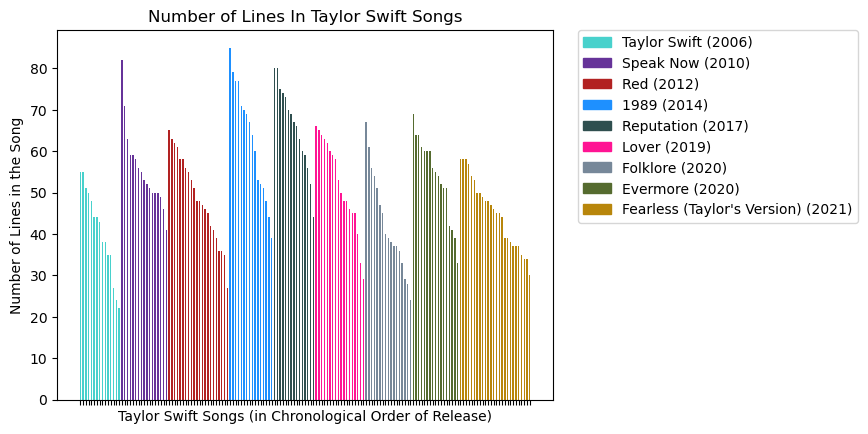

```python
fig, ax = plt.subplots()
names = lines_per_track["Track Name"]
number = lines_per_track["Number of Lines"]
ax.bar(names, number, color = colors, width = .5)

ax.xaxis.set_tick_params(labelbottom=False)
ax.set_xlabel("Taylor Swift Songs (in Chronological Order of Release)")
ax.set_ylabel("Number of Lines in the Song")
ax.set_title("Number of Lines In Taylor Swift Songs")

labels = list(album_colors.keys())
handles = [plt.Rectangle((0,0),1,1, color=album_colors[label]) for label in labels]
plt.legend(handles, labels, bbox_to_anchor=(1.05, 1), loc='upper left', borderaxespad=0)

plt.show()
```

#### The Average Number of Lines per Song in the Album

creating variables representing the average number of lines per song in each song

putting the averages into a single variable as a list

creating a two lists of strings: one is the names of the albums and one is the colors that correspond to each album

```python
avg_debut_lines_per_song = debut_lines_per_song.mean()
avg_speaknow_lines_per_song = speaknow_lines_per_song.mean()
avg_red_lines_per_song = red_lines_per_song.mean()
avg_nineteen89_lines_per_song = nineteen89_lines_per_song.mean()
avg_rep_lines_per_song = rep_lines_per_song.mean()
avg_lover_lines_per_song = lover_lines_per_song.mean()
avg_folk_lines_per_song = folk_lines_per_song.mean()
avg_ever_lines_per_song = ever_lines_per_song.mean()
avg_fearless_lines_per_song = fearless_lines_per_song.mean()

avg_lines_per_track = [avg_debut_lines_per_song, avg_speaknow_lines_per_song, avg_red_lines_per_song,
                       avg_nineteen89_lines_per_song, avg_rep_lines_per_song, avg_lover_lines_per_song,
                       avg_folk_lines_per_song, avg_ever_lines_per_song, avg_fearless_lines_per_song]

albums = ["Taylor Swift (2006)", "Speak Now (2010)", "Red (2012)", "1989 (2014)", "Reputation (2017)",
          "Lover (2019)", "Folklore (2020)", "Evermore (2020)", "Fearless (Taylor's Version) (2021)"]

avg_colors = ["mediumturquoise", "rebeccapurple", "firebrick", "dodgerblue", "darkslategrey", "deeppink",
              "lightslategray", "darkolivegreen", "darkgoldenrod"]
```

creating a bar graph with the average number of lines

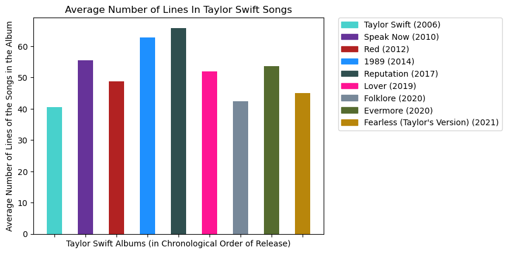

```python
fig, ax = plt.subplots()
ax.bar(albums, avg_lines_per_track, color = avg_colors, width = .5)

ax.xaxis.set_tick_params(labelbottom=False)
ax.set_xlabel("Taylor Swift Albums (in Chronological Order of Release)")
ax.set_ylabel("Average Number of Lines of the Songs in the Album")
ax.set_title("Average Number of Lines In Taylor Swift Songs")

labels = list(album_colors.keys())
handles = [plt.Rectangle((0,0),1,1, color=album_colors[label]) for label in labels]
plt.legend(handles, labels, bbox_to_anchor=(1.05, 1), loc='upper left', borderaxespad=0)

plt.show()
```

[figure not shown]

```python
xy = list(zip(year_of_release, avg_lines_per_track))
xy = np.array(xy)
x = xy[:, 0]
y = xy[:, 1]



theta = np.polyfit(x, y, 1)
r = theta[1] + theta[0]*x
plt.scatter(x, y, color = "midnightblue")
plt.plot(x, r, color = "midnightblue")

plt.title("Percentage of Songs by Taylor Swift Per Album, by Year")
plt.xlabel('Year of Album Release')
plt.ylabel("Percent of Songs in the Album out of Swift's entire discography")

plt.show()
```

### Proportions of Tracks by Album and Release Date

making the "Track Name" column of the indiviual album data frames into variables and then making them into lists

creating a variable that has the number of songs in each album

creating a variable that has the total amount of songs in all albums

creating a list of the percentages of songs in each album out of the total number of songs

```python
debut_songs = debut_songs["Track Name"]
speaknow_songs = speaknow_songs["Track Name"]
red_songs = red_songs["Track Name"]
nineteen89_songs = nineteen89_songs["Track Name"]
rep_songs = rep_songs["Track Name"]
lover_songs = lover_songs["Track Name"]
folk_songs = folk_songs["Track Name"]
ever_songs = ever_songs["Track Name"]
fearless_songs = fearless_songs["Track Name"]

debut_songs.tolist()
speaknow_songs.tolist()
red_songs.tolist()
nineteen89_songs.tolist()
rep_songs.tolist()
lover_songs.tolist()
folk_songs.tolist()
ever_songs.tolist()
fearless_songs.tolist()

debut_song_count = len(debut_songs)
speaknow_song_count = len(speaknow_songs)
red_song_count = len(red_songs)
nineteen89_song_count = len(nineteen89_songs)
rep_song_count = len(rep_songs)
lover_song_count = len(lover_songs)
folk_song_count = len(folk_songs)
ever_song_count = len(ever_songs)
fearless_song_count = len(fearless_songs)

all_song_count = debut_song_count + speaknow_song_count + red_song_count + nineteen89_song_count + rep_song_count + lover_song_count + folk_song_count + ever_song_count + fearless_song_count
percent_songs_per_album = [debut_song_count*100/all_song_count, speaknow_song_count*100/all_song_count, red_song_count*100/all_song_count, nineteen89_song_count*100/all_song_count, rep_song_count*100/all_song_count, lover_song_count*100/all_song_count, folk_song_count*100/all_song_count, ever_song_count*100/all_song_count, fearless_song_count*100/all_song_count]
```

creating a pie chart representing the albums and their proporitons of Taylor Swift's Discography

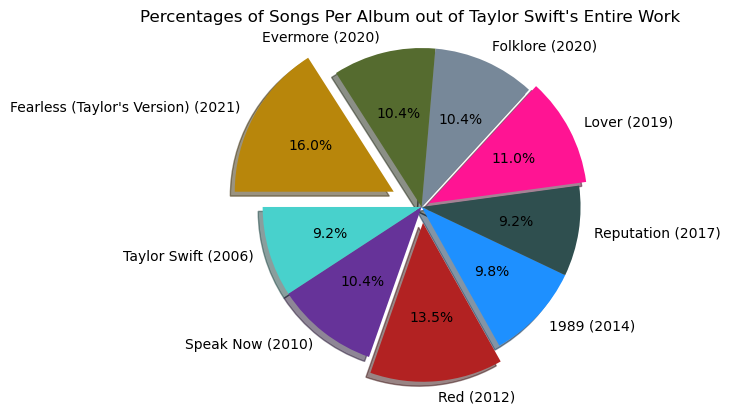

```python
fig1, ax1 = plt.subplots()
ax1.pie(percent_songs_per_album, explode=(0, 0, 0.1, 0, 0, 0.05, 0, 0, 0.2), labels=albums, autopct="%1.1f%%",
       shadow=True, startangle=180, colors = avg_colors)
ax1.axis("equal")
ax1.set_title("Percentages of Songs Per Album out of Taylor Swift's Entire Work")

plt.show()
```

creating a graph representing the year of releases of the album and the corresponding album's proporiton of Taylor Swift's Discography

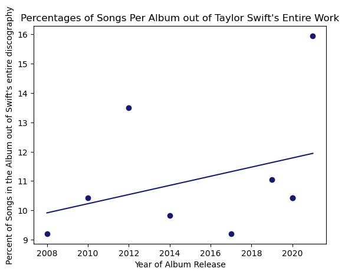

```python
xy = list(zip(year_of_release, percent_songs_per_album))
xy = np.array(xy)
x = xy[:, 0]
y = xy[:, 1]



theta = np.polyfit(x, y, 1)
r = theta[1] + theta[0]*x
plt.scatter(x, y, color = "midnightblue")
plt.plot(x, r, color = "midnightblue")

plt.title("Percentage of Songs by Taylor Swift Per Album, by Year")
plt.xlabel('Year of Album Release')
plt.ylabel("Percent of Songs in the Album out of Swift's entire discography")
plt.title("Percentages of Songs Per Album out of Taylor Swift's Entire Work")

plt.show()
```

### How has the themes and words mentioned in Taylor Swift's music changed over time?

creating a list for each album, containing the lyrics in the songs of the album

```python
debut_lyrics = list(debut["lyric"])
speaknow_lyrics = list(speaknow["lyric"])
red_lyrics = list(red["lyric"])
nineteen89_lyrics = list(nineteen89["lyric"])
rep_lyrics = list(rep["lyric"])
lover_lyrics = list(lover["lyric"])
folk_lyrics = list(folk["lyric"])
ever_lyrics = list(ever["lyric"])
fearless_lyrics = list(fearless["lyric"])
```

creating a set for each album containing the songs of the album in order to remove duplicates

```python
debut_tracklist = [*set(list(debut_tracks))]
speaknow_tracklist = [*set(list(speaknow_tracks))]
red_tracklist = [*set(list(red_tracks))]
nineteen89_tracklist = [*set(list(nineteen89_tracks))]
rep_tracklist = [*set(list(rep_tracks))]
lover_tracklist = [*set(list(lover_tracks))]
folk_tracklist = [*set(list(folk_tracks))]
ever_tracklist = [*set(list(ever_tracks))]
fearless_tracklist = [*set(list(fearless_tracks))]
```

#### Theme 1: Relationships

**Word Cited: Love**

creating a variable representing a string that will be the word we are checking for

creating an empty list for each category of song and each album

checking for the theme word using a "for" loop followed by an "if" statement

if the word is in the lyric, then it is added to the list of songs in the album that follow the category

```python
theme = "love"

debut_love_songs = []

for line in debut_lyrics:
    if theme in line:
        p = debut_lyrics.index(line)
        debut_love_songs.append(debut_tracks[p])


speaknow_love_songs = []

for line in speaknow_lyrics:
    if theme in line:
        p = speaknow_lyrics.index(line)
        speaknow_love_songs.append(speaknow_tracks[p])


red_love_songs = []

for line in red_lyrics:
    if theme in line:
        p = red_lyrics.index(line)
        red_love_songs.append(red_tracks[p])


nineteen89_love_songs = []

for line in nineteen89_lyrics:
    if theme in line:
        p = nineteen89_lyrics.index(line)
        nineteen89_love_songs.append(nineteen89_tracks[p])


rep_love_songs = []

for line in rep_lyrics:
    if theme in line:
        p = rep_lyrics.index(line)
        rep_love_songs.append(rep_tracks[p])


lover_love_songs = []

for line in lover_lyrics:
    if theme in line:
        p = lover_lyrics.index(line)
        lover_love_songs.append(lover_tracks[p])


folk_love_songs = []

for line in folk_lyrics:
    if theme in line:
        p = folk_lyrics.index(line)
        folk_love_songs.append(folk_tracks[p])


ever_love_songs = []

for line in ever_lyrics:
    if theme in line:
        p = ever_lyrics.index(line)
        ever_love_songs.append(ever_tracks[p])


fearless_love_songs = []

for line in fearless_lyrics:
    if theme in line:
        p = fearless_lyrics.index(line)
        fearless_love_songs.append(fearless_tracks[p])
```

changing the list of songs in the album that follow the category into a set to remove duplicates

creating a variable for each album, representing the percent of songs in the album in the category out of all of the songs on the album

```python
debut_love_songs = [*set(debut_love_songs)]
speaknow_love_songs = [*set(speaknow_love_songs)]
red_love_songs = [*set(red_love_songs)]
nineteen89_love_songs = [*set(nineteen89_love_songs)]
rep_love_songs = [*set(rep_love_songs)]
lover_love_songs = [*set(lover_love_songs)]
folk_love_songs = [*set(folk_love_songs)]
ever_love_songs = [*set(ever_love_songs)]
fearless_love_songs = [*set(fearless_love_songs)]

debut_percent_love = len(debut_love_songs)/len(debut_tracklist)
speaknow_percent_love = len(speaknow_love_songs)/len(speaknow_tracklist)
red_percent_love = len(red_love_songs)/len(red_tracklist)
nineteen89_percent_love = len(nineteen89_love_songs)/len(nineteen89_tracklist)
rep_percent_love = len(rep_love_songs)/len(rep_tracklist)
lover_percent_love = len(lover_love_songs)/len(lover_tracklist)
folk_percent_love = len(folk_love_songs)/len(folk_tracklist)
ever_percent_love = len(ever_love_songs)/len(ever_tracklist)
fearless_percent_love = len(fearless_love_songs)/len(fearless_tracklist)
```

#### Theme 2: Saddness

**Word Cited: Cry**

creating a variable representing a string that will be the word we are checking for

creating an empty list for each category of song and each album

checking for the theme word using a "for" loop followed by an "if" statement

if the word is in the lyric, then it is added to the list of songs in the album that follow the category

```python
theme = "cry"

debut_cry_songs = []

for line in debut_lyrics:
    if theme in line:
        p = debut_lyrics.index(line)
        debut_cry_songs.append(debut_tracks[p])


speaknow_cry_songs = []

for line in speaknow_lyrics:
    if theme in line:
        p = speaknow_lyrics.index(line)
        speaknow_cry_songs.append(speaknow_tracks[p])


red_cry_songs = []

for line in red_lyrics:
    if theme in line:
        p = red_lyrics.index(line)
        red_cry_songs.append(red_tracks[p])


nineteen89_cry_songs = []

for line in nineteen89_lyrics:
    if theme in line:
        p = nineteen89_lyrics.index(line)
        nineteen89_cry_songs.append(nineteen89_tracks[p])


rep_cry_songs = []

for line in rep_lyrics:
    if theme in line:
        p = rep_lyrics.index(line)
        rep_cry_songs.append(rep_tracks[p])


lover_cry_songs = []

for line in lover_lyrics:
    if theme in line:
        p = lover_lyrics.index(line)
        lover_cry_songs.append(lover_tracks[p])


folk_cry_songs = []

for line in folk_lyrics:
    if theme in line:
        p = folk_lyrics.index(line)
        folk_cry_songs.append(folk_tracks[p])


ever_cry_songs = []

for line in ever_lyrics:
    if theme in line:
        p = ever_lyrics.index(line)
        ever_cry_songs.append(ever_tracks[p])


fearless_cry_songs = []

for line in fearless_lyrics:
    if theme in line:
        p = fearless_lyrics.index(line)
        fearless_cry_songs.append(fearless_tracks[p])
```

changing the list of songs in the album that follow the category into a set

creating a variable for each album, representing the percent of songs in the album in the category out of all of the songs on the album

```python
debut_cry_songs = [*set(debut_cry_songs)]
speaknow_cry_songs = [*set(speaknow_cry_songs)]
red_cry_songs = [*set(red_cry_songs)]
nineteen89_cry_songs = [*set(nineteen89_cry_songs)]
rep_cry_songs = [*set(rep_cry_songs)]
lover_cry_songs = [*set(lover_cry_songs)]
folk_cry_songs = [*set(folk_cry_songs)]
ever_cry_songs = [*set(ever_cry_songs)]
fearless_cry_songs = [*set(fearless_cry_songs)]

debut_percent_cry = len(debut_cry_songs)/len(debut_tracklist)
speaknow_percent_cry = len(speaknow_cry_songs)/len(speaknow_tracklist)
red_percent_cry = len(red_cry_songs)/len(red_tracklist)
nineteen89_percent_cry = len(nineteen89_cry_songs)/len(nineteen89_tracklist)
rep_percent_cry = len(rep_cry_songs)/len(rep_tracklist)
lover_percent_cry = len(lover_cry_songs)/len(lover_tracklist)
folk_percent_cry = len(folk_cry_songs)/len(folk_tracklist)
ever_percent_cry = len(ever_cry_songs)/len(ever_tracklist)
fearless_percent_cry = len(fearless_cry_songs)/len(fearless_tracklist)
```

#### Theme 3: Perception

**Word Cited: Know**

creating a variable representing a string that will be the word we are checking for

creating an empty list for each category of song and each album

checking for the theme word using a "for" loop followed by an "if" statement

if the word is in the lyric, then it is added to the list of songs in the album that follow the category

```python
theme = "know"

debut_know_songs = []

for line in debut_lyrics:
    if theme in line:
        p = debut_lyrics.index(line)
        debut_know_songs.append(debut_tracks[p])


speaknow_know_songs = []

for line in speaknow_lyrics:
    if theme in line:
        p = speaknow_lyrics.index(line)
        speaknow_know_songs.append(speaknow_tracks[p])


red_know_songs = []

for line in red_lyrics:
    if theme in line:
        p = red_lyrics.index(line)
        red_know_songs.append(red_tracks[p])


nineteen89_know_songs = []

for line in nineteen89_lyrics:
    if theme in line:
        p = nineteen89_lyrics.index(line)
        nineteen89_know_songs.append(nineteen89_tracks[p])


rep_know_songs = []

for line in rep_lyrics:
    if theme in line:
        p = rep_lyrics.index(line)
        rep_know_songs.append(rep_tracks[p])


lover_know_songs = []

for line in lover_lyrics:
    if theme in line:
        p = lover_lyrics.index(line)
        lover_know_songs.append(lover_tracks[p])


folk_know_songs = []

for line in folk_lyrics:
    if theme in line:
        p = folk_lyrics.index(line)
        folk_know_songs.append(folk_tracks[p])


ever_know_songs = []

for line in ever_lyrics:
    if theme in line:
        p = ever_lyrics.index(line)
        ever_know_songs.append(ever_tracks[p])


fearless_know_songs = []

for line in fearless_lyrics:
    if theme in line:
        p = fearless_lyrics.index(line)
        fearless_know_songs.append(fearless_tracks[p])
```

changing the list of songs in the album that follow the category into a set

creating a variable for each album, representing the percent of songs in the album in the category out of all of the songs on the album

```python
debut_know_songs = [*set(debut_know_songs)]
speaknow_know_songs = [*set(speaknow_know_songs)]
red_know_songs = [*set(red_know_songs)]
nineteen89_know_songs = [*set(nineteen89_know_songs)]
rep_know_songs = [*set(rep_know_songs)]
lover_know_songs = [*set(lover_know_songs)]
folk_know_songs = [*set(folk_know_songs)]
ever_know_songs = [*set(ever_know_songs)]
fearless_know_songs = [*set(fearless_know_songs)]

debut_percent_know = len(debut_know_songs)/len(debut_tracklist)
speaknow_percent_know = len(speaknow_know_songs)/len(speaknow_tracklist)
red_percent_know = len(red_know_songs)/len(red_tracklist)
nineteen89_percent_know = len(nineteen89_know_songs)/len(nineteen89_tracklist)
rep_percent_know = len(rep_know_songs)/len(rep_tracklist)
lover_percent_know = len(lover_know_songs)/len(lover_tracklist)
folk_percent_know = len(folk_know_songs)/len(folk_tracklist)
ever_percent_know = len(ever_know_songs)/len(ever_tracklist)
fearless_percent_know = len(fearless_know_songs)/len(fearless_tracklist)
```

#### Theme 4: Romance

**Word Cited: Baby**

creating a variable representing a string that will be the word we are checking for

creating an empty list for each category of song and each album

checking for the theme word using a "for" loop followed by an "if" statement

if the word is in the lyric, then it is added to the list of songs in the album that follow the category

```python
theme = "baby"

debut_baby_songs = []

for line in debut_lyrics:
    if theme in line:
        p = debut_lyrics.index(line)
        debut_baby_songs.append(debut_tracks[p])


speaknow_baby_songs = []

for line in speaknow_lyrics:
    if theme in line:
        p = speaknow_lyrics.index(line)
        speaknow_baby_songs.append(speaknow_tracks[p])


red_baby_songs = []

for line in red_lyrics:
    if theme in line:
        p = red_lyrics.index(line)
        red_baby_songs.append(red_tracks[p])


nineteen89_baby_songs = []

for line in nineteen89_lyrics:
    if theme in line:
        p = nineteen89_lyrics.index(line)
        nineteen89_baby_songs.append(nineteen89_tracks[p])


rep_baby_songs = []

for line in rep_lyrics:
    if theme in line:
        p = rep_lyrics.index(line)
        rep_baby_songs.append(rep_tracks[p])


lover_baby_songs = []

for line in lover_lyrics:
    if theme in line:
        p = lover_lyrics.index(line)
        lover_baby_songs.append(lover_tracks[p])


folk_baby_songs = []

for line in folk_lyrics:
    if theme in line:
        p = folk_lyrics.index(line)
        folk_baby_songs.append(folk_tracks[p])


ever_baby_songs = []

for line in ever_lyrics:
    if theme in line:
        p = ever_lyrics.index(line)
        ever_baby_songs.append(ever_tracks[p])


fearless_baby_songs = []

for line in fearless_lyrics:
    if theme in line:
        p = fearless_lyrics.index(line)
        fearless_baby_songs.append(fearless_tracks[p])
```

changing the list of songs in the album that follow the category into a set

creating a variable for each album, representing the percent of songs in the album in the category out of all of the songs on the album

```python
debut_baby_songs = [*set(debut_baby_songs)]
speaknow_baby_songs = [*set(speaknow_baby_songs)]
red_baby_songs = [*set(red_baby_songs)]
nineteen89_baby_songs = [*set(nineteen89_baby_songs)]
rep_baby_songs = [*set(rep_baby_songs)]
lover_baby_songs = [*set(lover_baby_songs)]
folk_baby_songs = [*set(folk_baby_songs)]
ever_baby_songs = [*set(ever_baby_songs)]
fearless_baby_songs = [*set(fearless_baby_songs)]

debut_percent_baby = len(debut_baby_songs)/len(debut_tracklist)
speaknow_percent_baby = len(speaknow_baby_songs)/len(speaknow_tracklist)
red_percent_baby = len(red_baby_songs)/len(red_tracklist)
nineteen89_percent_baby = len(nineteen89_baby_songs)/len(nineteen89_tracklist)
rep_percent_baby = len(rep_baby_songs)/len(rep_tracklist)
lover_percent_baby = len(lover_baby_songs)/len(lover_tracklist)
folk_percent_baby = len(folk_baby_songs)/len(folk_tracklist)
ever_percent_baby = len(ever_baby_songs)/len(ever_tracklist)
fearless_percent_baby = len(fearless_baby_songs)/len(fearless_tracklist)
```

#### Theme 5: Ending

**Word Cited: Never**

creating a variable representing a string that will be the word we are checking for

creating an empty list for each category of song and each album

checking for the theme word using a "for" loop followed by an "if" statement

if the word is in the lyric, then it is added to the list of songs in the album that follow the category

```python
theme = "never"

debut_never_songs = []

for line in debut_lyrics:
    if theme in line:
        p = debut_lyrics.index(line)
        debut_never_songs.append(debut_tracks[p])


speaknow_never_songs = []

for line in speaknow_lyrics:
    if theme in line:
        p = speaknow_lyrics.index(line)
        speaknow_never_songs.append(speaknow_tracks[p])


red_never_songs = []

for line in red_lyrics:
    if theme in line:
        p = red_lyrics.index(line)
        red_never_songs.append(red_tracks[p])


nineteen89_never_songs = []

for line in nineteen89_lyrics:
    if theme in line:
        p = nineteen89_lyrics.index(line)
        nineteen89_never_songs.append(nineteen89_tracks[p])


rep_never_songs = []

for line in rep_lyrics:
    if theme in line:
        p = rep_lyrics.index(line)
        rep_never_songs.append(rep_tracks[p])


lover_never_songs = []

for line in lover_lyrics:
    if theme in line:
        p = lover_lyrics.index(line)
        lover_never_songs.append(lover_tracks[p])


folk_never_songs = []

for line in folk_lyrics:
    if theme in line:
        p = folk_lyrics.index(line)
        folk_never_songs.append(folk_tracks[p])


ever_never_songs = []

for line in ever_lyrics:
    if theme in line:
        p = ever_lyrics.index(line)
        ever_never_songs.append(ever_tracks[p])


fearless_never_songs = []

for line in fearless_lyrics:
    if theme in line:
        p = fearless_lyrics.index(line)
        fearless_never_songs.append(fearless_tracks[p])
```

changing the list of songs in the album that follow the category into a set

creating a variable for each album, representing the percent of songs in the album in the category out of all of the songs on the album

```python
debut_never_songs = [*set(debut_never_songs)]
speaknow_never_songs = [*set(speaknow_never_songs)]
red_never_songs = [*set(red_never_songs)]
nineteen89_never_songs = [*set(nineteen89_never_songs)]
rep_never_songs = [*set(rep_never_songs)]
lover_never_songs = [*set(lover_never_songs)]
folk_never_songs = [*set(folk_never_songs)]
ever_never_songs = [*set(ever_never_songs)]
fearless_never_songs = [*set(fearless_never_songs)]

debut_percent_never = len(debut_never_songs)/len(debut_tracklist)
speaknow_percent_never = len(speaknow_never_songs)/len(speaknow_tracklist)
red_percent_never = len(red_never_songs)/len(red_tracklist)
nineteen89_percent_never = len(nineteen89_never_songs)/len(nineteen89_tracklist)
rep_percent_never = len(rep_never_songs)/len(rep_tracklist)
lover_percent_never = len(lover_never_songs)/len(lover_tracklist)
folk_percent_never = len(folk_never_songs)/len(folk_tracklist)
ever_percent_never = len(ever_never_songs)/len(ever_tracklist)
fearless_percent_never = len(fearless_never_songs)/len(fearless_tracklist)
```

creating a list containing each of words that we checked the lyrics for

creating a dictionary with the theme and its corresponding color

creating lists for each of the themes with every percentage of songs in each album in each category

```python
themes = ["love", "cry", "know", "baby", "never"]

theme_colors = {"Love" : "lightpink",
                "Cry" : "lightskyblue",
                "Know" : "darkgreen",
                "Baby" : "mediumpurple",
                "Never" : "indianred"}

all_love_percent = [debut_percent_love*100, speaknow_percent_love*100, red_percent_love*100,
                    nineteen89_percent_love*100, rep_percent_love*100, lover_percent_love*100,
                    folk_percent_love*100, ever_percent_love*100, fearless_percent_love*100]

all_cry_percent = [debut_percent_cry*100, speaknow_percent_cry*100, red_percent_cry*100,
                    nineteen89_percent_cry*100, rep_percent_cry*100, lover_percent_cry*100,
                    folk_percent_cry*100, ever_percent_cry*100, fearless_percent_cry*100]

all_know_percent = [debut_percent_know*100, speaknow_percent_know*100, red_percent_know*100,
                    nineteen89_percent_know*100, rep_percent_know*100, lover_percent_know*100,
                    folk_percent_know*100, ever_percent_know*100, fearless_percent_know*100]

all_baby_percent = [debut_percent_baby*100, speaknow_percent_baby*100, red_percent_baby*100,
                    nineteen89_percent_baby*100, rep_percent_baby*100, lover_percent_baby*100,
                    folk_percent_baby*100, ever_percent_baby*100, fearless_percent_baby*100]

all_never_percent = [debut_percent_never*100, speaknow_percent_never*100, red_percent_never*100,
                    nineteen89_percent_never*100, rep_percent_never*100, lover_percent_never*100,
                    folk_percent_never*100, ever_percent_never*100, fearless_percent_never*100]
```

creating an array out for each of the themes, with the first column being the year of release for the corresponding album and the second being percentage of songs in the that follow the theme

```python
love = list(zip(year_of_release, all_love_percent))
love = np.array(love)

cry = list(zip(year_of_release, all_cry_percent))
cry = np.array(cry)

know = list(zip(year_of_release, all_know_percent))
know = np.array(know)

baby = list(zip(year_of_release, all_baby_percent))
baby = np.array(baby)

never = list(zip(year_of_release, all_never_percent))
never = np.array(never)
```

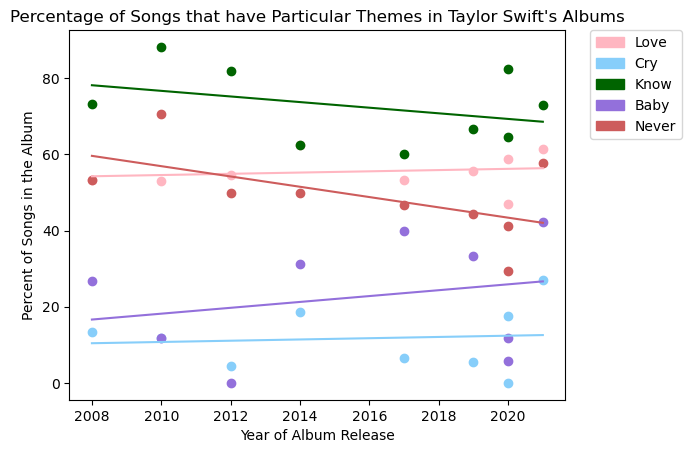

```python
x1 = love[:, 0]
y1 = love[:, 1]
theta = np.polyfit(x1, y1, 1)
r1 = theta[1] + theta[0]*x1
plt.scatter(x1, y1, color = "lightpink")
plt.plot(x1, r1, color = "lightpink")

x2 = cry[:, 0]
y2 = cry[:, 1]
theta = np.polyfit(x2, y2, 1)
r2 = theta[1] + theta[0]*x2
plt.scatter(x2, y2, color = "lightskyblue")
plt.plot(x2, r2, color = "lightskyblue")

x3 = know[:, 0]
y3 = know[:, 1]
theta = np.polyfit(x3, y3, 1)
r3 = theta[1] + theta[0]*x3
plt.scatter(x3, y3, color = "darkgreen")
plt.plot(x3, r3, color = "darkgreen")

x4 = baby[:, 0]
y4 = baby[:, 1]
theta = np.polyfit(x4, y4, 1)
r4 = theta[1] + theta[0]*x4
plt.scatter(x4, y4, color = "mediumpurple")
plt.plot(x4, r4, color = "mediumpurple")

x5 = never[:, 0]
y5 = never[:, 1]
theta = np.polyfit(x5, y5, 1)
r5 = theta[1] + theta[0]*x5
plt.scatter(x5, y5, color = "indianred")
plt.plot(x5, r5, color = "indianred")

plt.title("Percentage of Songs that have Particular Themes in Taylor Swift's Albums")
plt.xlabel('Year of Album Release')
plt.ylabel('Percent of Songs in the Album')


labels = list(theme_colors.keys())
handles = [plt.Rectangle((0,0),1,1, color=theme_colors[label]) for label in labels]
plt.legend(handles, labels, bbox_to_anchor=(1.05, 1), loc='upper left', borderaxespad=0)

plt.show()
```

## Citations

Data Obtained: https://www.kaggle.com/datasets/thespacefreak/taylor-swift-song-lyrics-all-albums

Removing The Labels for Each Bar on the X-Axis of the Bar Graph: https://www.tutorialspoint.com/how-to-turn-off-the-ticks-and-marks-of-a-matlibplot-axes#:~:text=Plot%20x%20and%20y%20data,and%20Y%20axes%20tick%20marks.

Different Colors: https://matplotlib.org/stable/gallery/color/named_colors.html

Location of the Legend: http://matlab.izmiran.ru/help/techdoc/ref/legend.html

The Colors and The Legend: https://www.mathworks.com/help/matlab/ref/legend.html#bt6r30y

Concatenating Objects: https://pandas.pydata.org/docs/user_guide/merging.html

Instructions to Create a Line of Best Fit: https://www.statology.org/line-of-best-fit-python/

Removing Duplicates: https://www.geeksforgeeks.org/python-ways-to-remove-duplicates-from-list/